# Project Part 1

Maria Lefevre

22 May, 2020

# Packages and Data

```r
setwd("~/Northland College/Great Graphs")
library(tidyverse)
library(patchwork)
```

```r
be <- read.csv("BRWE.csv")
be$Season <- factor(be$Season, levels = c("S", "F"), labels = c("Spring", "Fall"))
be$Stream <- factor(be$Stream, levels = c("Head", "Mid", "Lower"))
str(be)

## Bad River Watershed
br <- read.csv("Bad River.csv")
br$Season <- factor(br$Season, levels = c("S", "F"), labels = c("Spring", "Fall"))
br$Stream <- factor(br$Stream, levels = c("Head", "Mid", "Lower"))
str(br)

cbPalette <- c("Head"="#000000", "Lower"="#56B4E9","Mid"="#CC79A7")
```

```r
p <- ggplot(data = be, mapping = aes(x=Year, y=pEPT, color=Stream)) +
  geom_point(size=5, alpha=0.25) +
  geom_jitter(width = 0.1, height = 0.02, size = 5, alpha = 0.25) +
  scale_x_continuous(breaks = seq(2004, 2020, 2),
                     expand = expansion(mult = c(0.03, 0.05))) +
  scale_y_continuous(breaks = seq(20,100,20), limits = c(20,100),
                     expand = expansion(mult = c(0.07,0.05)),
                     labels = function(x) paste0(x, "%")) +
  scale_color_manual(values=cbPalette, ) +
  geom_smooth(method = "loess", se=FALSE) +
  theme_bw() +
  theme(panel.grid = element_blank(),
        strip.text = element_text(size=12, face = "bold"),
        panel.spacing=unit(4,unit="mm"), axis.text = element_text(size=10),
        plot.title = element_text(size = 16), legend.position = "none") +
  labs(title = "Marcoinvertebrate % EPT for the Bad River Watershed, 2004-2018",
       caption = "Source: Superior Rivers Watershed Association") +
  facet_grid(vars(Season)) +
  labs(x=element_blank(),
       y=element_blank(),
       color="Stream Reach")
```

# Bad River Watershed HBI

The goal of this graph is to illustrate the HBI values for the different reaches on the Bad River watershed over the years between the seasons spring and fall so to get an idea of the water quality.

```
#R> `geom_smooth()` using formula 'y ~ x'
```

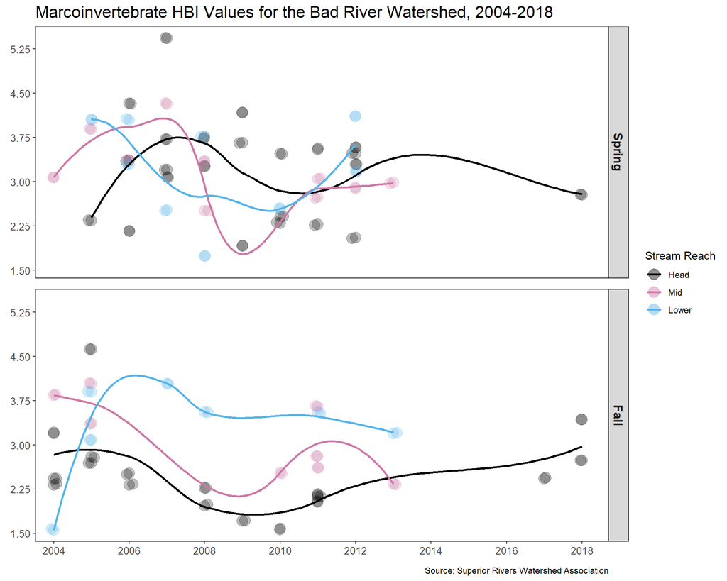

```r
B <- ggplot(data = br, mapping = aes(x=Year, y=HBI, color=Stream)) +
  geom_point(size=5, alpha=0.25) +
  geom_jitter(width = 0.1, height = 0.02, size = 5, alpha = 0.25) +
  scale_x_continuous(breaks = seq(2004, 2020, 2),
                     expand = expansion(mult = c(0.03, 0.05))) +
  scale_y_continuous(breaks = seq(0, 6, 0.75)) +
  scale_color_manual(values=cbPalette, ) +
  geom_smooth(method = "loess", se=FALSE) +
  theme_bw() +
  theme(panel.grid = element_blank(),
        strip.text = element_text(size=12, face = "bold"),
        panel.spacing=unit(4,unit="mm"), axis.text = element_text(size=10),
        plot.title = element_text(size = 16)) +
  labs(title = "Marcoinvertebrate HBI Values for the Bad River Watershed, 2004-2018",
       caption = "Source: Superior Rivers Watershed Association") +
  facet_grid(vars(Season)) +
  labs(x=element_blank(),
       y=element_blank(),
       color="Stream Reach")
B
```

This graph shows that the fall samples have a more consistent trend for HBI values over the years compared to the spring samples. The fall samples tend to be lower in values, meaning that the water quality is better, then in spring were it appears to be more inconsistent. The fall graphic shows that the HBI value of the head waters is starting to increase in value starting in 2017, this could have been a result of the hundred year floods. The years between 2008 and 2013 had the lowest HBI values, indicating that the water quality was at its best during this period. The spring data is more inconsistent then the fall. One hypothesis about why this could be is the spring melt bringing more runoff into the watershed then in the fall. Over all in the water quality of the Bad River Watershed is between Good and Excellent.